# London Housing Dataset Analysis

### LONDON HOUSING DATASET

This dataset is primarily centerd around the housing market of London. It contains a lot of additional relevant data:

- Monthly average house prices
- Yearly number of houses sold
- Monthly number of crimes commited

The data used here is from year 1995 to 2019 of each different area.

This data is available as a CSV file, downloaded from Kaggle.

We will analyze this data using the Pandas DataFrame.

Here, random sets of questions are given for which we have to fin correct results.

This project is for beginners and for those who want to know how we analyze big data with Python.

```python
#import pandas lib
import pandas as pd
```

```python
#import the dataset
data = pd.read_csv(r"E:\DATA SETS\London Housing Data.csv")
print("Dataset imported")
```

```
Dataset imported
```

```python
data
```

|  | date | area | average_price | code | houses_sold | no_of_crimes |
| --- | --- | --- | --- | --- | --- | --- |
| 0 | 1/1/1995 | city of london | 91449 | E09000001 | 17.0 | NaN |
| 1 | 2/1/1995 | city of london | 82203 | E09000001 | 7.0 | NaN |
| 2 | 3/1/1995 | city of london | 79121 | E09000001 | 14.0 | NaN |
| 3 | 4/1/1995 | city of london | 77101 | E09000001 | 7.0 | NaN |
| 4 | 5/1/1995 | city of london | 84409 | E09000001 | 10.0 | NaN |
| ... | ... | ... | ... | ... | ... | ... |
| 13544 | 9/1/2019 | england | 249942 | E92000001 | 64605.0 | NaN |
| 13545 | 10/1/2019 | england | 249376 | E92000001 | 68677.0 | NaN |
| 13546 | 11/1/2019 | england | 248515 | E92000001 | 67814.0 | NaN |
| 13547 | 12/1/2019 | england | 250410 | E92000001 | NaN | NaN |
| 13548 | 1/1/2020 | england | 247355 | E92000001 | NaN | NaN |

13549 rows × 6 columns

```python
# df.count()
data.count()
```

```
date             13549
area             13549
average_price    13549
code             13549
houses_sold      13455
no_of_crimes      7439
dtype: int64
```

```python
# df.isnull().sum()
data.isnull().sum()
```

```
date                0
area                0
average_price       0
code                0
houses_sold        94
no_of_crimes     6110
dtype: int64
```

```python
# Import seaborn as sns
# Import matplotlib.pyplot as plt
import seaborn as sns
import matplotlib.pyplot as plt
```

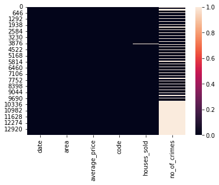

```python
# sns.heatmap(df.isnull())
sns.heatmap(data.isnull())
```

### Convert the Datatype of 'Date' column to Date-Time format

```python
data.head()
```

|  | date | area | average_price | code | houses_sold | no_of_crimes |
| --- | --- | --- | --- | --- | --- | --- |
| 0 | 1/1/1995 | city of london | 91449 | E09000001 | 17.0 | NaN |
| 1 | 2/1/1995 | city of london | 82203 | E09000001 | 7.0 | NaN |
| 2 | 3/1/1995 | city of london | 79121 | E09000001 | 14.0 | NaN |
| 3 | 4/1/1995 | city of london | 77101 | E09000001 | 7.0 | NaN |
| 4 | 5/1/1995 | city of london | 84409 | E09000001 | 10.0 | NaN |

```python
#data.dtypes
data.dtypes # date column is an object datatype
```

```
date              object
area              object
average_price      int64
code              object
houses_sold      float64
no_of_crimes     float64
dtype: object
```

```python
#data.date = pd.to_datetime(data.date)
data.date = pd.to_datetime(data.date)
print('Date field type updated')
```

```
Date field type updated
```

```python
#check data.dtypes
data.dtypes
```

```
date             datetime64[ns]
area                     object
average_price             int64
code                     object
houses_sold             float64
no_of_crimes            float64
dtype: object
```

### Add a new column "year" in the dataframe, which contains years only

```python
data.head()
```

|  | date | area | average_price | code | houses_sold | no_of_crimes |
| --- | --- | --- | --- | --- | --- | --- |
| 0 | 1995-01-01 | city of london | 91449 | E09000001 | 17.0 | NaN |
| 1 | 1995-02-01 | city of london | 82203 | E09000001 | 7.0 | NaN |
| 2 | 1995-03-01 | city of london | 79121 | E09000001 | 14.0 | NaN |
| 3 | 1995-04-01 | city of london | 77101 | E09000001 | 7.0 | NaN |
| 4 | 1995-05-01 | city of london | 84409 | E09000001 | 10.0 | NaN |

```python
#data['year'] = data.Date_Column.dt.year
data['year'] = data.date.dt.year
print('year column created')
```

```
year column created
```

```python
data.head()
```

|  | date | area | average_price | code | houses_sold | no_of_crimes | year |
| --- | --- | --- | --- | --- | --- | --- | --- |
| 0 | 1995-01-01 | city of london | 91449 | E09000001 | 17.0 | NaN | 1995 |
| 1 | 1995-02-01 | city of london | 82203 | E09000001 | 7.0 | NaN | 1995 |
| 2 | 1995-03-01 | city of london | 79121 | E09000001 | 14.0 | NaN | 1995 |
| 3 | 1995-04-01 | city of london | 77101 | E09000001 | 7.0 | NaN | 1995 |
| 4 | 1995-05-01 | city of london | 84409 | E09000001 | 10.0 | NaN | 1995 |

### Add a new column 'month' as 2nd column in the dataframe, which contain month only

```python
#data.insert(1 , 'month' , data.date.drt.month)
data.insert(1 , 'month' , data.date.dt.month)
```

```python
data.head()
```

|  | date | month | area | average_price | code | houses_sold | no_of_crimes | year |
| --- | --- | --- | --- | --- | --- | --- | --- | --- |
| 0 | 1995-01-01 | 1 | city of london | 91449 | E09000001 | 17.0 | NaN | 1995 |
| 1 | 1995-02-01 | 2 | city of london | 82203 | E09000001 | 7.0 | NaN | 1995 |
| 2 | 1995-03-01 | 3 | city of london | 79121 | E09000001 | 14.0 | NaN | 1995 |
| 3 | 1995-04-01 | 4 | city of london | 77101 | E09000001 | 7.0 | NaN | 1995 |
| 4 | 1995-05-01 | 5 | city of london | 84409 | E09000001 | 10.0 | NaN | 1995 |

### Remove the columns 'year' and 'month' from the dataframe

```python
#data.drop(['month', 'year'] , axis=1, inplace=True)
data.drop(['month', 'year'] , axis=1, inplace=True)
print('columns month and year are deleted')
```

```
columns month and year are deleted
```

```python
data.head()
```

|  | date | area | average_price | code | houses_sold | no_of_crimes |
| --- | --- | --- | --- | --- | --- | --- |
| 0 | 1995-01-01 | city of london | 91449 | E09000001 | 17.0 | NaN |
| 1 | 1995-02-01 | city of london | 82203 | E09000001 | 7.0 | NaN |
| 2 | 1995-03-01 | city of london | 79121 | E09000001 | 14.0 | NaN |
| 3 | 1995-04-01 | city of london | 77101 | E09000001 | 7.0 | NaN |
| 4 | 1995-05-01 | city of london | 84409 | E09000001 | 10.0 | NaN |

### Show all the records where 'no_if_crimes' is 0. And, how many such records are there?

```python
data.no_of_crimes == 0
```

```
0        False
1        False
2        False
3        False
4        False
         ...
13544    False
13545    False
13546    False
13547    False
13548    False
Name: no_of_crimes, Length: 13549, dtype: bool
```

```python
data[data.no_of_crimes == 0]
```

|  | date | area | average_price | code | houses_sold | no_of_crimes |
| --- | --- | --- | --- | --- | --- | --- |
| 72 | 2001-01-01 | city of london | 284262 | E09000001 | 24.0 | 0.0 |
| 73 | 2001-02-01 | city of london | 198137 | E09000001 | 37.0 | 0.0 |
| 74 | 2001-03-01 | city of london | 189033 | E09000001 | 44.0 | 0.0 |
| 75 | 2001-04-01 | city of london | 205494 | E09000001 | 38.0 | 0.0 |
| 76 | 2001-05-01 | city of london | 223459 | E09000001 | 30.0 | 0.0 |
| ... | ... | ... | ... | ... | ... | ... |
| 178 | 2009-11-01 | city of london | 397909 | E09000001 | 11.0 | 0.0 |
| 179 | 2009-12-01 | city of london | 411955 | E09000001 | 16.0 | 0.0 |
| 180 | 2010-01-01 | city of london | 464436 | E09000001 | 20.0 | 0.0 |
| 181 | 2010-02-01 | city of london | 490525 | E09000001 | 9.0 | 0.0 |
| 182 | 2010-03-01 | city of london | 498241 | E09000001 | 15.0 | 0.0 |

104 rows × 6 columns

```python
#len(data[data.no_of_crimes == 0])
len(data[data.no_of_crimes == 0])
```

```
104
```

### What is the maximum & minimum 'average_price' per year in England?

```python
#create the year column first
data['year'] = data.date.dt.year
print('year column created')
```

```
year column created
```

```python
data.head()
```

|  | date | area | average_price | code | houses_sold | no_of_crimes | year |
| --- | --- | --- | --- | --- | --- | --- | --- |
| 0 | 1995-01-01 | city of london | 91449 | E09000001 | 17.0 | NaN | 1995 |
| 1 | 1995-02-01 | city of london | 82203 | E09000001 | 7.0 | NaN | 1995 |
| 2 | 1995-03-01 | city of london | 79121 | E09000001 | 14.0 | NaN | 1995 |
| 3 | 1995-04-01 | city of london | 77101 | E09000001 | 7.0 | NaN | 1995 |
| 4 | 1995-05-01 | city of london | 84409 | E09000001 | 10.0 | NaN | 1995 |

```python
#df1 = data[data.area == 'england']
df1 = data[data.area == 'england']
df1
```

|  | date | area | average_price | code | houses_sold | no_of_crimes | year |
| --- | --- | --- | --- | --- | --- | --- | --- |
| 13248 | 1995-01-01 | england | 53203 | E92000001 | 47639.0 | NaN | 1995 |
| 13249 | 1995-02-01 | england | 53096 | E92000001 | 47880.0 | NaN | 1995 |
| 13250 | 1995-03-01 | england | 53201 | E92000001 | 67025.0 | NaN | 1995 |
| 13251 | 1995-04-01 | england | 53591 | E92000001 | 56925.0 | NaN | 1995 |
| 13252 | 1995-05-01 | england | 53678 | E92000001 | 64192.0 | NaN | 1995 |
| ... | ... | ... | ... | ... | ... | ... | ... |
| 13544 | 2019-09-01 | england | 249942 | E92000001 | 64605.0 | NaN | 2019 |
| 13545 | 2019-10-01 | england | 249376 | E92000001 | 68677.0 | NaN | 2019 |
| 13546 | 2019-11-01 | england | 248515 | E92000001 | 67814.0 | NaN | 2019 |
| 13547 | 2019-12-01 | england | 250410 | E92000001 | NaN | NaN | 2019 |
| 13548 | 2020-01-01 | england | 247355 | E92000001 | NaN | NaN | 2020 |

301 rows × 7 columns

```python
#df1.groupby('year').average_price.max()/min()/mean()
df1.groupby('year')
```

```
<pandas.core.groupby.generic.DataFrameGroupBy object at 0x00000161AF11E6A0>
```

```python
#max prices
df1.groupby('year').average_price.max()
```

```
year
1995     53901
1996     55755
1997     61564
1998     65743
1999     75071
2000     84191
2001     95992
2002    119982
2003    138985
2004    160330
2005    167244
2006    182031
2007    194764
2008    191750
2009    174136
2010    180807
2011    177335
2012    180129
2013    188544
2014    203639
2015    219582
2016    231922
2017    242628
2018    248620
2019    250410
2020    247355
Name: average_price, dtype: int64
```

```python
#min prices
df1.groupby('year').average_price.min()
```

```
year
1995     52788
1996     52333
1997     55789
1998     61659
1999     65522
2000     75219
2001     84245
2002     96215
2003    121610
2004    139719
2005    158572
2006    166544
2007    181824
2008    165795
2009    159340
2010    174458
2011    173046
2012    174161
2013    176816
2014    188265
2015    202856
2016    220361
2017    231593
2018    240428
2019    243281
2020    247355
Name: average_price, dtype: int64
```

```python
#mean values
df1.groupby('year').average_price.mean()
```

```
year
1995     53322.416667
1996     54151.500000
1997     59160.666667
1998     64301.666667
1999     70070.750000
2000     80814.333333
2001     90306.750000
2002    107981.500000
2003    130218.583333
2004    152314.416667
2005    163570.000000
2006    174351.500000
2007    190025.583333
2008    182379.916667
2009    166558.666667
2010    177472.666667
2011    175230.000000
2012    177488.000000
2013    182581.416667
2014    197771.083333
2015    211174.750000
2016    227337.166667
2017    238161.166667
2018    245018.333333
2019    247101.083333
2020    247355.000000
Name: average_price, dtype: float64
```

### What is the Max & Min no_of_crimes recorded per area?

```python
#data.groupby('area').no_of_crimes.max()
```

```python
data.groupby('area')
```

```
<pandas.core.groupby.generic.DataFrameGroupBy object at 0x00000161AF0DE220>
```

```python
#max
data.groupby('area').no_of_crimes.max().sort_values(ascending =True)
```

```
area
city of london              10.0
kingston upon thames      1379.0
sutton                    1425.0
richmond upon thames      1551.0
merton                    1623.0
harrow                    1763.0
bexley                    1914.0
havering                  1956.0
barking and dagenham      2049.0
redbridge                 2560.0
bromley                   2637.0
hammersmith and fulham    2645.0
kensington and chelsea    2778.0
enfield                   2798.0
lewisham                  2813.0
hounslow                  2817.0
hillingdon                2819.0
greenwich                 2853.0
barnet                    2893.0
brent                     2937.0
waltham forest            2941.0
wandsworth                3051.0
haringey                  3199.0
croydon                   3263.0
tower hamlets             3316.0
islington                 3384.0
ealing                    3401.0
hackney                   3466.0
newham                    3668.0
southwark                 3821.0
camden                    4558.0
lambeth                   4701.0
westminster               7461.0
east midlands                NaN
east of england              NaN
england                      NaN
inner london                 NaN
london                       NaN
north east                   NaN
north west                   NaN
outer london                 NaN
south east                   NaN
south west                   NaN
west midlands                NaN
yorks and the humber         NaN
Name: no_of_crimes, dtype: float64
```

```python
#min
data.groupby('area').no_of_crimes.min().sort_values(ascending =True)
```

```
area
city of london               0.0
kingston upon thames       692.0
richmond upon thames       700.0
sutton                     787.0
merton                     819.0
bexley                     860.0
harrow                     937.0
havering                  1130.0
barking and dagenham      1217.0
hammersmith and fulham    1323.0
kensington and chelsea    1347.0
bromley                   1441.0
hillingdon                1445.0
redbridge                 1487.0
greenwich                 1513.0
hounslow                  1529.0
haringey                  1536.0
waltham forest            1575.0
wandsworth                1582.0
enfield                   1635.0
tower hamlets             1646.0
lewisham                  1675.0
barnet                    1703.0
brent                     1850.0
hackney                   1870.0
ealing                    1871.0
islington                 1871.0
croydon                   2031.0
camden                    2079.0
newham                    2130.0
southwark                 2267.0
lambeth                   2381.0
westminster               3504.0
east midlands                NaN
east of england              NaN
england                      NaN
inner london                 NaN
london                       NaN
north east                   NaN
north west                   NaN
outer london                 NaN
south east                   NaN
south west                   NaN
west midlands                NaN
yorks and the humber         NaN
Name: no_of_crimes, dtype: float64
```

```python
#mean
data.groupby('area').no_of_crimes.mean().sort_values(ascending =True)
```

```
area
city of london               0.423423
kingston upon thames       991.790393
richmond upon thames      1041.620087
sutton                    1078.213974
merton                    1208.615721
harrow                    1256.598253
bexley                    1299.458515
havering                  1530.358079
barking and dagenham      1599.275109
kensington and chelsea    1833.222707
hammersmith and fulham    1914.676856
redbridge                 1940.480349
bromley                   2020.131004
hounslow                  2040.231441
enfield                   2077.921397
waltham forest            2113.598253
hillingdon                2141.768559
greenwich                 2154.899563
wandsworth                2209.716157
barnet                    2278.441048
lewisham                  2296.458515
haringey                  2406.427948
brent                     2415.602620
islington                 2515.991266
tower hamlets             2542.253275
hackney                   2575.751092
ealing                    2607.061135
croydon                   2652.943231
newham                    2851.432314
southwark                 3028.563319
camden                    3056.572052
lambeth                   3141.720524
westminster               5291.454148
east midlands                     NaN
east of england                   NaN
england                           NaN
inner london                      NaN
london                            NaN
north east                        NaN
north west                        NaN
outer london                      NaN
south east                        NaN
south west                        NaN
west midlands                     NaN
yorks and the humber              NaN
Name: no_of_crimes, dtype: float64
```

### Show the total count of records of each area, where average price is less than 100000

```python
#data[data.average_price < 100000].area.value_counts()
```

```python
data.average_price < 100000
```

```
0         True
1         True
2         True
3         True
4         True
         ...
13544    False
13545    False
13546    False
13547    False
13548    False
Name: average_price, Length: 13549, dtype: bool
```

```python
data[data.average_price < 100000]
```

|  | date | area | average_price | code | houses_sold | no_of_crimes | year |
| --- | --- | --- | --- | --- | --- | --- | --- |
| 0 | 1995-01-01 | city of london | 91449 | E09000001 | 17.0 | NaN | 1995 |
| 1 | 1995-02-01 | city of london | 82203 | E09000001 | 7.0 | NaN | 1995 |
| 2 | 1995-03-01 | city of london | 79121 | E09000001 | 14.0 | NaN | 1995 |
| 3 | 1995-04-01 | city of london | 77101 | E09000001 | 7.0 | NaN | 1995 |
| 4 | 1995-05-01 | city of london | 84409 | E09000001 | 10.0 | NaN | 1995 |
| ... | ... | ... | ... | ... | ... | ... | ... |
| 13330 | 2001-11-01 | england | 95083 | E92000001 | 109149.0 | NaN | 2001 |
| 13331 | 2001-12-01 | england | 95992 | E92000001 | 93329.0 | NaN | 2001 |
| 13332 | 2002-01-01 | england | 96215 | E92000001 | 71678.0 | NaN | 2002 |
| 13333 | 2002-02-01 | england | 96676 | E92000001 | 77131.0 | NaN | 2002 |
| 13334 | 2002-03-01 | england | 98962 | E92000001 | 102828.0 | NaN | 2002 |

2209 rows × 7 columns

```python
data[data.average_price < 100000].area.value_counts()
```

```
north east              112
north west              111
yorks and the humber    110
east midlands            96
west midlands            94
england                  87
barking and dagenham     85
south west               78
east of england          76
newham                   72
bexley                   64
waltham forest           64
lewisham                 62
havering                 60
south east               59
greenwich                59
croydon                  57
enfield                  54
sutton                   54
hackney                  53
redbridge                52
southwark                48
tower hamlets            47
outer london             46
hillingdon               44
lambeth                  41
hounslow                 41
brent                    40
london                   39
merton                   35
haringey                 33
bromley                  33
inner london             31
ealing                   31
kingston upon thames     30
harrow                   30
wandsworth               26
barnet                   25
islington                19
city of london           11
Name: area, dtype: int64
```

**By DataSpieler12345**